# Майнор "Интеллектуальный анализ данных"

# Курс "Введение в анализ данных"

# Лабораторная работа №1. Обработка и первичный анализ данных

## Суворов Артём Андреевич, 19БИ-3

## Данные

В рамках данной лабораторной работы вам предлагается проанализировать набор данных о студентах двух школ в Португалии.  
В файле `students_data.csv` представлена информация о студентах, посещающих два курса - математику (`Math`) и поргутальский язык (`Por`). Некоторые студенты представлены в обоих курсах, некоторые - только в одном. Для каждого студента известны три оценки по курсу: оценка за первое полугодие (`G1`), оценка за второе полугодие (`G2`) и итоговая оценка за год (`G3`).

```python
import pandas as pd
import seaborn as sns
import matplotlib.pyplot as plt

sns.set(rc={'figure.figsize':(12, 8)})
```

```python
pd.set_option('display.max_columns', None)
pd.set_option('display.max_colwidth', None)
```

```python
data = pd.read_csv("students_data.csv")
data.shape
```

```
(1044, 36)
```

```python
data.head(15)
```

|  | ID | Subject | school | sex | age | address | famsize | Pstatus | Medu | Fedu | Mjob | Fjob | reason | guardian | traveltime | studytime | failures | schoolsup | famsup | paid | activities | nursery | higher | internet | romantic | famrel | freetime | goout | Dalc | … |
| --- | --- | --- | --- | --- | --- | --- | --- | --- | --- | --- | --- | --- | --- | --- | --- | --- | --- | --- | --- | --- | --- | --- | --- | --- | --- | --- | --- | --- | --- | --- |
| 0 | 100097 | Por | GP | F | 16 | U | GT3 | A | 3 | 4 | services | other | course | father | 1 | 1 | 0 | no | no | no | no | yes | yes | yes | no | 3.0 | 2 | 1 | 1.0 | … |
| 1 | 101021 | Por | GP | F | 17 | U | GT3 | T | 3 | 2 | other | other | course | mother | 1 | 2 | 0 | no | no | no | yes | no | yes | yes | no | 5.0 | 3 | 4 | 1.0 | … |
| 2 | 102965 | Por | GP | M | 16 | U | LE3 | T | 1 | 2 | health | services | course | mother | 2 | 1 | 2 | no | no | no | no | no | yes | yes | no | 4.0 | 4 | 5 | 3.0 | … |
| 3 | 102989 | Por | MS | M | 17 | U | GT3 | T | 2 | 3 | other | services | home | father | 2 | 2 | 0 | no | no | no | yes | yes | yes | yes | no | 4.0 | 4 | 3 | 1.0 | … |
| 4 | 103131 | Por | GP | F | 16 | U | GT3 | T | 1 | 1 | at_home | other | home | mother | 2 | 1 | 0 | no | yes | no | no | yes | yes | no | NaN | 4.0 | 3 | 2 | 1.0 | … |
| 5 | 103144 | Por | GP | M | 18 | U | LE3 | T | 3 | 1 | services | services | course | mother | 2 | 1 | 0 | no | no | no | yes | yes | yes | yes | yes | 3.0 | 3 | 4 | 4.0 | … |
| 6 | 105257 | Por | MS | F | 18 | U | GT3 | T | 1 | 1 | other | other | course | mother | 2 | 2 | 0 | no | no | no | yes | yes | yes | no | no | 1.0 | 1 | 1 | 1.0 | … |
| 7 | 107639 | Por | MS | F | 15 | R | GT3 | T | 4 | 4 | teacher | other | course | mother | 2 | 1 | 0 | no | no | no | no | yes | yes | yes | yes | 1.0 | 5 | 1 | 3.0 | … |
| 8 | 107914 | Math | GP | F | 15 | U | LE3 | T | 3 | 2 | services | other | reputation | mother | 1 | 2 | 0 | no | yes | yes | no | yes | yes | yes | no | 4.0 | 4 | 4 | 1.0 | … |
| 9 | 108089 | Por | MS | M | 16 | R | GT3 | T | 3 | 4 | other | health | other | mother | 3 | 2 | 0 | no | no | no | no | no | yes | no | no | 3.0 | 4 | 5 | 1.0 | … |
| 10 | 108254 | Por | GP | M | 15 | U | LE3 | T | 4 | 4 | health | services | course | father | 1 | 1 | 0 | no | yes | no | yes | yes | yes | yes | no | 4.0 | 3 | 3 | 1.0 | … |
| 11 | 108296 | Por | GP | M | 18 | U | LE3 | T | 3 | 4 | services | other | home | mother | 1 | 2 | 0 | no | no | no | yes | yes | yes | yes | yes | 4.0 | 3 | 3 | 1.0 | … |
| 12 | 108753 | Math | MS | F | 18 | R | GT3 | T | 4 | 4 | teacher | at-home | reputation | mother | 3 | 1 | 0 | no | yes | yes | yes | yes | yes | yes | yes | 4.0 | 4 | 3 | 2.0 | … |
| 13 | 108825 | Por | GP | M | 15 | U | GT3 | T | 4 | 3 | teacher | other | home | mother | 1 | 2 | 0 | no | yes | no | yes | yes | yes | yes | no | 4.0 | 3 | 3 | 2.0 | … |
| 14 | 114462 | Math | GP | F | 16 | U | LE3 | T | 2 | 2 | at_home | other | course | mother | 1 | 2 | 0 | no | yes | no | no | yes | yes | no | no | 4.0 | 3 | 4 | 1.0 | … |

### Признаки

Данные представлены признаками различных типов: числовыми, категориальными, упорядоченными категориальными.

**Описание признаков:**

```python
pd.read_csv('students_data_features.csv',
            delimiter=';',
            encoding='windows-1251')
```

|  | Признак | Описание |
| --- | --- | --- |
| 0 | ID | Уникальный номер наблюдения |
| 1 | Subject | Предмет: 'Math' - математика, 'Por' - португальский язык |
| 2 | school | Школа: 'GP' - Gabriel Pereira, 'MS' - Mousinho da Silveira |
| 3 | sex | Пол студента: 'F' - женский, 'M' - мужской |
| 4 | age | Возраст студента |
| 5 | address | Место проживания студента: 'U' - в городе, 'R' - за городом |
| 6 | famsize | Число членов семьи: 'LE3' - если <= 3, 'GT3' - если > 3 |
| 7 | Pstatus | Отношения родителей: 'T' - живут вместе, 'A' - живут раздельно |
| 8 | Medu | Образование матери: 0 - без образования, 1 - начальная школа, 2 – от 5 до 9 классов, 3 – среднее образование, 4 – высшее образование |
| 9 | Fedu | Образование отца: 0 - без образования, 1 - начальная школа, 2 – от 5 до 9 классов, 3 – среднее образование, 4 – высшее образование |
| 10 | Mjob | Работа матери: 'teacher' - связана с преподаванием, 'health' - связана с здравоохранением, 'services' - администрация и полиция, 'at_home' - домашняя занятость, 'other' - другое |
| 11 | Fjob | Работа отца: 'teacher' - связана с преподаванием, 'health' - связана с здравоохранением, 'services' - администрация и полиция, 'at_home' - домашняя занятость, 'other' - другое |
| 12 | reason | Причина, по которой студент выбрал данную школу: 'home' - рядом с домом, 'reputation' - репутация школы, 'course' - читаемые курсы, 'other' - другое |
| 13 | guardian | Опекун студента (student's guardian): 'mother', 'father' или 'other' |
| 14 | traveltime | Время в пути от дома до школы: 1 - < 15 мин, 2 - от 15 до 30 мин, 3 - от 30 мин до 1 часа, 4 - > 1 часа |
| 15 | studytime | Количество часов на учебу в неделю: 1 - < 2 часов, 2 - от 2 до 5 часов, 3 - от 5 до 10 часов, 4 - > 10 часов |
| 16 | failures | Число завалов студента по предыдущим курсам: n если 0<=n<3, иначе 3 |
| 17 | schoolsup | Дополнительная помощь в учебе: yes или no |
| 18 | famsup | Дополнительная помощь в учебе от членов семьи: yes или no |
| 19 | paid | Платные дополнительные занятия по соответствущему курсу ('Math' или 'Por'): yes или no |
| 20 | activities | Внеучебные активности: yes или no |
| 21 | nursery | Ходил в детстве в детский сад: yes или no |
| 22 | higher | Собирается получать высшее образование: yes или no |
| 23 | internet | Есть доступ к всемирной сети из дома: yes или no |
| 24 | romantic | Состоит в романтических отношениях: yes или no |
| 25 | famrel | Отношения в семье: от 1 - очень плохие, до 5 - прекрасные |
| 26 | freetime | Свободное время после занятий: от 1 - очень мало, до 5 - очень много |
| 27 | goout | Проводит время с друзьями: от 1 - очень редко/мало, до 5 - очень часто/много |
| 28 | Dalc | Потребление алкоголя в будни: от 1 - очень мало, до 5 - очень много |
| 29 | Walc | Потребление алкоголя в выходные: от 1 - очень мало, до 5 - очень много |
| 30 | health | Состояние здоровья: от 1 - очень плохое, до 5 - очень хорошее |
| 31 | absences | Число пропусков: сколько раз пропустил занятия в школе |
| 32 | cheating | Списывает ли на тестах: yes или no |
| 33 | G1 | Оценка за первое полугодние: от 0 до 20 |
| 34 | G2 | Оценка за второе полугодие: от 0 до 20 |
| 35 | G3 | Итоговая оценка: от 0 до 20 |

## Задания

**NB:** Обратите внимание, что часть студентов посещают оба курса и представлены в данных два раза. Из-за этого некоторые результаты анализа могут быть искажены. Имеет смысл выявить таких студентов заранее (Задание 11) и учитывать эту информацию при анализе.

### Задание 1

- Для каждого признака определите, к какому типу он относится.
- Проверьте значения признаков на наличие опечаток и ошибок, исправьте их.  
  **Note:** Исправлять ошибки нужно программно, модифицировать руками исходный файл нельзя.
- При необходимости, приведите признак к определенному вами типу.

Получение типов признаков

```python
data.dtypes
```

```
ID              int64
Subject        object
school         object
sex            object
age             int64
address        object
famsize        object
Pstatus        object
Medu           object
Fedu           object
Mjob           object
Fjob           object
reason         object
guardian       object
traveltime      int64
studytime       int64
failures        int64
schoolsup      object
famsup         object
paid           object
activities     object
nursery        object
higher         object
internet       object
romantic       object
famrel        float64
freetime        int64
goout           int64
Dalc          float64
Walc          float64
health          int64
absences        int64
cheating       object
G1              int64
G2              int64
G3              int64
dtype: object
```

Посмотрим, какие в принципе существуют значения у признаков в данных

```python
for column in data.columns:
    print(f'{column} : {data[column].unique()}')
```

```
ID : [100097 101021 102965 ... 998425 999143 999194]
Subject : ['Por' 'Math']
school : ['GP' 'MS']
sex : ['F' 'M' 'm']
age : [16 17 18 15 19 21 20 22]
address : ['U' 'R']
famsize : ['GT3' 'LE3']
Pstatus : ['A' 'T' 't']
Medu : ['3' '1' '2' '4' '0' 'o']
Fedu : ['4' '2' '3' '1' 'o' '0']
Mjob : ['services' 'other' 'health' 'at_home' 'teacher' 'at-home']
Fjob : ['other' 'services' 'health' 'at-home' 'teacher' 'at_home']
reason : ['course' 'home' 'reputation' 'other']
guardian : ['father' 'mother' 'other' 'futher']
traveltime : [1 2 3 4]
studytime : [1 2 4 3]
failures : [0 2 1 3]
schoolsup : ['no' 'yes']
famsup : ['no' 'yes']
paid : ['no' 'yes']
activities : ['no' 'yes']
nursery : ['yes' 'no']
higher : ['yes' 'no']
internet : ['yes' 'no']
romantic : ['no' nan 'yes']
famrel : [ 3.  5.  4.  1.  2. nan]
freetime : [2 3 4 1 5]
goout : [1 4 5 3 2]
Dalc : [ 1.  3.  4.  2.  5. nan]
Walc : [ 4.  3.  5.  1.  2. nan]
health : [5 3 4 2 1]
absences : [12  2  0  4  6 10  7 20 14 11 24  8 16 21  1 18  5 22  9  3 15 26 25 54
 56 40 19 13 38 30 17 28 32 23 75]
cheating : [nan 'yes' 'no']
G1 : [15 17  9 14 12 11 13  7 16  6  8 10 18  0  5  3  4 19]
G2 : [13 18  8 15 11 12 14  6 10 16  5  7  9 17  0  4 19]
G3 : [14 17 10 16 13 12  9  6 11  8 18 15  0  5  7 19  4  1 20]
```

Можно видеть, что немного опечаток присутствует. Обработаем их индивидуально

В данном случае исправлению будут подвержены следующие яцейки:

- sex
- Pstatus
- Medu
- Fedu
- Mjob
- Fjob
- guardian

```python
for i in range(data.shape[0]):
    data.at[i, 'sex'] = data.at[i, 'sex'].upper()
    data.at[i, 'Pstatus'] = data.at[i, 'Pstatus'].upper()

    for letter in ['M', 'F']:
        if data.at[i, f'{letter}edu'] == 'o':
            data.at[i, f'{letter}edu'] = '0'
        data.at[i, f'{letter}edu'] = int(data.at[i, f'{letter}edu'])
        data.at[i, f'{letter}job'] = data.at[i, f'{letter}job'].replace('-', '_')

    if data.at[i, 'guardian'] == 'futher':
        data.at[i, 'guardian'] = 'father'

data.Medu = data.Medu.astype('int64')
data.Fedu = data.Fedu.astype('int64')
```

Посмотрим, что получилось

```python
for column in data.columns:
    print(f'{column} : {data[column].unique()}')
```

```
ID : [100097 101021 102965 ... 998425 999143 999194]
Subject : ['Por' 'Math']
school : ['GP' 'MS']
sex : ['F' 'M']
age : [16 17 18 15 19 21 20 22]
address : ['U' 'R']
famsize : ['GT3' 'LE3']
Pstatus : ['A' 'T']
Medu : [3 1 2 4 0]
Fedu : [4 2 3 1 0]
Mjob : ['services' 'other' 'health' 'at_home' 'teacher']
Fjob : ['other' 'services' 'health' 'at_home' 'teacher']
reason : ['course' 'home' 'reputation' 'other']
guardian : ['father' 'mother' 'other']
traveltime : [1 2 3 4]
studytime : [1 2 4 3]
failures : [0 2 1 3]
schoolsup : ['no' 'yes']
famsup : ['no' 'yes']
paid : ['no' 'yes']
activities : ['no' 'yes']
nursery : ['yes' 'no']
higher : ['yes' 'no']
internet : ['yes' 'no']
romantic : ['no' nan 'yes']
famrel : [ 3.  5.  4.  1.  2. nan]
freetime : [2 3 4 1 5]
goout : [1 4 5 3 2]
Dalc : [ 1.  3.  4.  2.  5. nan]
Walc : [ 4.  3.  5.  1.  2. nan]
health : [5 3 4 2 1]
absences : [12  2  0  4  6 10  7 20 14 11 24  8 16 21  1 18  5 22  9  3 15 26 25 54
 56 40 19 13 38 30 17 28 32 23 75]
cheating : [nan 'yes' 'no']
G1 : [15 17  9 14 12 11 13  7 16  6  8 10 18  0  5  3  4 19]
G2 : [13 18  8 15 11 12 14  6 10 16  5  7  9 17  0  4 19]
G3 : [14 17 10 16 13 12  9  6 11  8 18 15  0  5  7 19  4  1 20]
```

Признаки edu родителей были приведены к числовому виду (как были задуманы)

### Задание 2

Проверьте, присутствуют ли в данных пропущенные значения. Сколько? В каких признаках?  
По каждому такому признаку предложите и обоснуйте, что делать с пропущенными значениями.

```python
data.isna().sum()
```

```
ID              0
Subject         0
school          0
sex             0
age             0
address         0
famsize         0
Pstatus         0
Medu            0
Fedu            0
Mjob            0
Fjob            0
reason          0
guardian        0
traveltime      0
studytime       0
failures        0
schoolsup       0
famsup          0
paid            0
activities      0
nursery         0
higher          0
internet        0
romantic       10
famrel         10
freetime        0
goout           0
Dalc           10
Walc           10
health          0
absences        0
cheating      700
G1              0
G2              0
G3              0
dtype: int64
```

Рассмотрим признаки romantic, famrel, Dalc и Walc. Первое, что можно предложить - удалить записи, т.к. их немного относительно всей выборки

Теперь рассмотрим признак cheating. Как видно, у него больше всего пропущенных значений. Можно удалить весь признак целиком (удалять записи не стоит - потеряется больше половины данных).

Второе, что можно предложить - заполнить случайными значениями те признаки, значения которых 'yes' и 'no' (romantic и cheating). Стоит посчитать их частоту в датасете и использовать её как вероятность при проставлении.

Третье - заполнить famrel и -alc-признаки медианными значениями. Это не сильно изменит распределение и эту неточность можно допустить, т.к. пропущенных занчений относительно мало

```python
print(data[(data.romantic.isna()) | (data.famrel.isna()) | (data.Dalc.isna()) | (data.Walc.isna())].shape)
data[(data.romantic.isna()) | (data.famrel.isna()) | (data.Dalc.isna()) | (data.Walc.isna())]
```

```
(40, 36)
```

|  | ID | Subject | school | sex | age | address | famsize | Pstatus | Medu | Fedu | Mjob | Fjob | reason | guardian | traveltime | studytime | failures | schoolsup | famsup | paid | activities | nursery | higher | internet | romantic | famrel | freetime | goout | Dalc | … |
| --- | --- | --- | --- | --- | --- | --- | --- | --- | --- | --- | --- | --- | --- | --- | --- | --- | --- | --- | --- | --- | --- | --- | --- | --- | --- | --- | --- | --- | --- | --- |
| 4 | 103131 | Por | GP | F | 16 | U | GT3 | T | 1 | 1 | at_home | other | home | mother | 2 | 1 | 0 | no | yes | no | no | yes | yes | no | NaN | 4.0 | 3 | 2 | 1.0 | … |
| 36 | 131767 | Por | GP | F | 16 | U | LE3 | T | 4 | 4 | teacher | teacher | reputation | mother | 1 | 2 | 0 | no | yes | no | no | yes | yes | yes | no | 4.0 | 5 | 2 | 1.0 | … |
| 85 | 164833 | Por | GP | F | 16 | U | GT3 | T | 2 | 2 | services | other | reputation | mother | 2 | 2 | 0 | no | no | no | yes | no | yes | yes | no | NaN | 4 | 4 | 1.0 | … |
| 116 | 189712 | Math | GP | M | 16 | U | LE3 | A | 3 | 4 | services | other | home | mother | 1 | 2 | 0 | yes | yes | no | yes | yes | yes | yes | no | NaN | 3 | 3 | 1.0 | … |
| 141 | 207086 | Por | GP | F | 16 | U | LE3 | T | 2 | 4 | other | health | course | father | 2 | 2 | 0 | no | yes | no | yes | yes | yes | yes | yes | 4.0 | 2 | 2 | NaN | … |
| 146 | 212614 | Math | GP | F | 19 | U | LE3 | T | 1 | 1 | at_home | other | reputation | other | 1 | 2 | 1 | yes | yes | no | yes | no | yes | yes | no | NaN | 4 | 3 | 1.0 | … |
| 159 | 224690 | Por | GP | M | 17 | U | LE3 | T | 2 | 3 | services | services | reputation | father | 1 | 2 | 0 | no | yes | no | no | no | yes | yes | no | NaN | 3 | 3 | 1.0 | … |
| 196 | 254236 | Por | GP | F | 17 | U | GT3 | T | 4 | 2 | other | other | reputation | mother | 2 | 3 | 0 | no | yes | no | no | yes | yes | yes | no | 4.0 | 3 | 3 | 1.0 | … |
| 242 | 299441 | Math | GP | M | 15 | U | LE3 | A | 3 | 2 | services | other | home | mother | 1 | 2 | 0 | no | yes | yes | no | yes | yes | yes | no | 4.0 | 2 | 2 | 1.0 | … |
| 294 | 349524 | Math | GP | F | 15 | U | GT3 | T | 4 | 4 | teacher | health | reputation | mother | 1 | 2 | 0 | no | yes | yes | no | yes | yes | yes | no | 3.0 | 3 | 3 | 1.0 | … |
| 326 | 373767 | Por | MS | F | 17 | U | GT3 | T | 4 | 2 | teacher | services | home | mother | 1 | 2 | 0 | yes | yes | no | yes | yes | yes | yes | NaN | 5.0 | 5 | 5 | 1.0 | … |
| 349 | 395183 | Por | GP | F | 15 | U | GT3 | T | 4 | 4 | services | services | course | mother | 1 | 1 | 0 | yes | yes | no | no | yes | yes | yes | no | 3.0 | 3 | 4 | 2.0 | … |
| 367 | 416298 | Por | MS | M | 18 | R | GT3 | T | 3 | 2 | services | other | course | mother | 1 | 1 | 1 | no | no | no | no | yes | no | yes | NaN | 2.0 | 3 | 1 | 2.0 | … |
| 381 | 423547 | Por | MS | M | 17 | R | LE3 | T | 1 | 2 | at_home | services | reputation | mother | 1 | 1 | 0 | no | yes | no | yes | yes | yes | yes | NaN | 5.0 | 5 | 5 | 5.0 | … |
| 386 | 429129 | Math | GP | M | 15 | U | GT3 | T | 4 | 2 | teacher | other | home | mother | 1 | 2 | 0 | no | yes | yes | no | yes | yes | no | no | 4.0 | 3 | 3 | NaN | … |
| 398 | 434990 | Por | GP | M | 16 | U | GT3 | T | 4 | 4 | health | other | course | mother | 1 | 1 | 0 | no | yes | no | yes | yes | yes | yes | no | NaN | 4 | 4 | 1.0 | … |
| 400 | 435403 | Math | GP | M | 17 | U | LE3 | A | 3 | 2 | teacher | services | home | mother | 1 | 1 | 1 | no | no | no | no | yes | yes | yes | NaN | 4.0 | 4 | 4 | 3.0 | … |
| 402 | 439005 | Math | GP | F | 16 | R | GT3 | T | 3 | 3 | services | other | reputation | father | 1 | 3 | 1 | yes | yes | no | yes | yes | yes | yes | no | 4.0 | 1 | 2 | 1.0 | … |
| 432 | 466451 | Math | GP | F | 17 | U | GT3 | A | 2 | 1 | other | other | course | mother | 2 | 3 | 0 | no | no | no | yes | yes | yes | yes | yes | 3.0 | 2 | 3 | 1.0 | … |
| 434 | 469435 | Math | MS | M | 19 | R | GT3 | T | 1 | 1 | other | other | home | other | 3 | 1 | 1 | no | yes | no | no | yes | yes | yes | no | NaN | 4 | 4 | 3.0 | … |
| 455 | 486246 | Por | GP | F | 15 | U | GT3 | T | 4 | 4 | services | teacher | other | father | 1 | 2 | 0 | yes | yes | no | yes | no | yes | yes | no | NaN | 4 | 4 | 1.0 | … |
| 461 | 492293 | Por | GP | F | 17 | U | GT3 | A | 4 | 4 | other | teacher | home | mother | 2 | 2 | 0 | yes | yes | no | no | yes | yes | no | NaN | 4.0 | 1 | 4 | 1.0 | … |
| 478 | 504919 | Por | GP | F | 19 | U | LE3 | A | 2 | 3 | at_home | other | home | other | 2 | 1 | 1 | no | no | no | no | yes | no | yes | no | NaN | 2 | 3 | 3.0 | … |
| 489 | 515594 | Por | GP | M | 16 | U | LE3 | T | 4 | 3 | services | other | reputation | mother | 1 | 2 | 0 | no | yes | no | yes | yes | yes | yes | NaN | 5.0 | 4 | 2 | 1.0 | … |
| 498 | 520417 | Math | GP | F | 16 | U | GT3 | T | 2 | 1 | other | other | course | mother | 1 | 2 | 0 | no | yes | yes | no | yes | yes | no | yes | 4.0 | 3 | 5 | 1.0 | … |
| 516 | 544841 | Math | GP | F | 15 | U | GT3 | T | 1 | 1 | other | other | home | father | 1 | 2 | 0 | no | yes | no | yes | no | yes | yes | NaN | 4.0 | 3 | 2 | 2.0 | … |
| 602 | 624719 | Por | GP | M | 18 | R | LE3 | T | 3 | 2 | services | other | reputation | mother | 2 | 3 | 0 | no | yes | no | yes | yes | yes | yes | no | NaN | 4 | 2 | 1.0 | … |
| 650 | 654030 | Por | GP | F | 16 | U | GT3 | T | 4 | 3 | teacher | other | other | mother | 1 | 2 | 0 | no | no | no | yes | yes | yes | yes | yes | 1.0 | 3 | 2 | NaN | … |
| 660 | 662126 | Math | GP | M | 15 | U | GT3 | T | 4 | 3 | teacher | other | home | mother | 1 | 2 | 0 | no | yes | yes | yes | yes | yes | yes | no | 4.0 | 3 | 3 | NaN | … |
| 716 | 718669 | Por | GP | F | 15 | R | LE3 | T | 2 | 2 | health | services | reputation | mother | 2 | 2 | 0 | yes | yes | no | no | yes | yes | yes | no | 4.0 | 1 | 3 | NaN | … |
| 722 | 722408 | Math | GP | F | 17 | U | GT3 | T | 3 | 2 | other | other | course | mother | 1 | 2 | 0 | no | no | no | yes | no | yes | yes | no | 5.0 | 3 | 4 | NaN | … |
| 730 | 730585 | Por | MS | F | 16 | R | GT3 | T | 1 | 1 | at_home | other | course | father | 2 | 2 | 3 | yes | yes | no | no | yes | yes | no | NaN | 3.0 | 4 | 3 | 1.0 | … |
| 739 | 735371 | Por | MS | F | 15 | U | GT3 | T | 2 | 2 | other | services | course | mother | 2 | 3 | 0 | no | yes | no | yes | yes | yes | no | no | 5.0 | 3 | 2 | NaN | … |
| 802 | 793239 | Por | MS | F | 17 | R | GT3 | T | 0 | 0 | at_home | other | course | mother | 2 | 1 | 0 | no | yes | no | no | yes | yes | yes | no | 4.0 | 4 | 3 | 1.0 | … |
| 820 | 807503 | Math | GP | M | 15 | U | GT3 | T | 4 | 3 | teacher | other | reputation | mother | 1 | 2 | 0 | no | no | no | no | yes | yes | yes | no | NaN | 4 | 1 | 1.0 | … |
| 969 | 942277 | Por | GP | F | 17 | U | LE3 | T | 2 | 1 | other | other | home | father | 1 | 2 | 0 | no | no | no | yes | yes | yes | yes | no | 4.0 | 2 | 3 | 2.0 | … |
| 970 | 944567 | Por | GP | F | 17 | U | GT3 | A | 2 | 1 | other | other | course | mother | 2 | 3 | 0 | no | no | no | yes | yes | yes | yes | NaN | 3.0 | 2 | 3 | 1.0 | … |
| 1008 | 975759 | Math | GP | F | 15 | U | GT3 | T | 4 | 4 | teacher | teacher | course | mother | 2 | 1 | 0 | no | no | no | yes | yes | yes | yes | no | 4.0 | 3 | 2 | NaN | … |
| 1041 | 998425 | Por | MS | F | 16 | R | LE3 | T | 1 | 1 | at_home | other | course | father | 3 | 2 | 0 | no | yes | no | no | yes | yes | no | no | 5.0 | 3 | 2 | NaN | … |
| 1043 | 999194 | Por | GP | M | 17 | R | GT3 | T | 1 | 3 | other | other | course | father | 3 | 2 | 1 | no | yes | no | yes | yes | yes | yes | no | 5.0 | 2 | 4 | NaN | … |

Остановимся на следующем варианте: удалить строки с пропусками и удалить колонку

```python
data_wout_na = data.dropna(subset=['romantic', 'famrel', 'Dalc', 'Walc'])
data_wout_na = data_wout_na.drop(columns=['cheating'])
print(data_wout_na.shape)
print(data.shape)

data_wout_na.isna().sum()
```

```
(1004, 35)
(1044, 36)
```

```
ID            0
Subject       0
school        0
sex           0
age           0
address       0
famsize       0
Pstatus       0
Medu          0
Fedu          0
Mjob          0
Fjob          0
reason        0
guardian      0
traveltime    0
studytime     0
failures      0
schoolsup     0
famsup        0
paid          0
activities    0
nursery       0
higher        0
internet      0
romantic      0
famrel        0
freetime      0
goout         0
Dalc          0
Walc          0
health        0
absences      0
G1            0
G2            0
G3            0
dtype: int64
```

### Задание 3

Проанализируйте данные на наличие выбросов.  
Сколько наблюдений можно отнести к выбросам по каждому признаку? Сколько всего выбросов в данных?

**Note:** Выбросы можно не удалять из данных. Это информацию можно учитывать в дальнейшем анализе и удалять выбросы при необходимости.

```
ID int64
age int64
Medu int64
Fedu int64
traveltime int64
studytime int64
failures int64
famrel float64
freetime int64
goout int64
Dalc float64
Walc float64
health int64
absences int64
G1 int64
G2 int64
G3 int64
```

```
age              AxesSubplot(0.125,0.772143;0.227941x0.107857)
Medu          AxesSubplot(0.398529,0.772143;0.227941x0.107857)
Fedu          AxesSubplot(0.672059,0.772143;0.227941x0.107857)
traveltime       AxesSubplot(0.125,0.642714;0.227941x0.107857)
studytime     AxesSubplot(0.398529,0.642714;0.227941x0.107857)
failures      AxesSubplot(0.672059,0.642714;0.227941x0.107857)
famrel           AxesSubplot(0.125,0.513286;0.227941x0.107857)
freetime      AxesSubplot(0.398529,0.513286;0.227941x0.107857)
goout         AxesSubplot(0.672059,0.513286;0.227941x0.107857)
Dalc             AxesSubplot(0.125,0.383857;0.227941x0.107857)
Walc          AxesSubplot(0.398529,0.383857;0.227941x0.107857)
health        AxesSubplot(0.672059,0.383857;0.227941x0.107857)
absences         AxesSubplot(0.125,0.254429;0.227941x0.107857)
G1            AxesSubplot(0.398529,0.254429;0.227941x0.107857)
G2            AxesSubplot(0.672059,0.254429;0.227941x0.107857)
G3                  AxesSubplot(0.125,0.125;0.227941x0.107857)
dtype: object
```

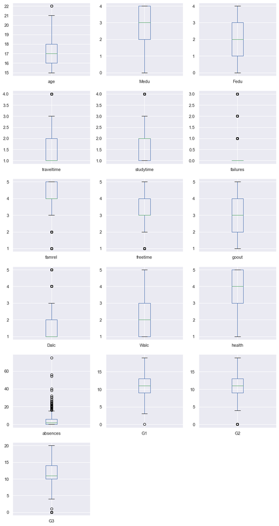

```python
numeric_data = []

for column, dtype in zip(data.columns, data.dtypes):
    if dtype == 'int64' or dtype == 'float64':
        print(column, dtype)
        numeric_data.append(column)

data[numeric_data[1:]].plot.box(subplots=True, layout=(6, 3), figsize=(12, 24))
```

```python
outliers = {}

for column in numeric_data[1:]:
    Q1 = data[column].quantile(0.25)
    Q3 = data[column].quantile(0.75)
    IQR = Q3 - Q1  #IQR это диапазон между квантилями

    filter_ = (data[column] >= Q1 - 1.5 * IQR) & (data[column] <= Q3 + 1.5 * IQR)  # определили допустимый диапазон

    outliers[column] = data.shape[0] - data.loc[filter_].shape[0]  # всего минус не-выбросы

print(outliers)
```

```
{'age': 2, 'Medu': 0, 'Fedu': 0, 'traveltime': 24, 'studytime': 62, 'failures': 183, 'famrel': 86, 'freetime': 64, 'goout': 0, 'Dalc': 62, 'Walc': 10, 'health': 0, 'absences': 54, 'G1': 1, 'G2': 20, 'G3': 54}
```

Failures можно убрать, т.к. это больше похоже на категориальный признак, чем на дискретный

```python
del outliers['failures']
```

```python
for col, score in outliers.items():
    print(f'{col}: {score}')

print('all: ', sum(outliers.values()))
```

```
age: 2
Medu: 0
Fedu: 0
traveltime: 24
studytime: 62
famrel: 86
freetime: 64
goout: 0
Dalc: 62
Walc: 10
health: 0
absences: 54
G1: 1
G2: 20
G3: 54
all:  439
```

### Задание 4

- Посчитайте описательные статистики для числовых и для категориальных признаков.
- Сколько студентов посещают каждую из школ?
- Сколько студентов посещают математику, сколько - португальский?
- Студенты какого курса чаще заваливают экзамены?
- Сколько в среднем времени в неделю уходит на учебу по каждому предмету?
- На что чаще обращают внимание при выборе школы?

Описательная статистика для числовых признаков

```python
data.describe()
```

|  | ID | age | Medu | Fedu | traveltime | studytime | failures | famrel | freetime | goout | Dalc | Walc | health | absences | G1 | G2 | G3 |
| --- | --- | --- | --- | --- | --- | --- | --- | --- | --- | --- | --- | --- | --- | --- | --- | --- | --- |
| count | 1044.000000 | 1044.000000 | 1044.000000 | 1044.000000 | 1044.000000 | 1044.000000 | 1044.000000 | 1034.000000 | 1044.000000 | 1044.000000 | 1034.000000 | 1034.000000 | 1044.000000 | 1044.000000 | 1044.000000 | 1044.000000 | 1044.000000 |
| mean | 547057.190613 | 16.726054 | 2.603448 | 2.387931 | 1.522989 | 1.970307 | 0.264368 | 3.936170 | 3.201149 | 3.156130 | 1.497099 | 2.291103 | 3.543103 | 4.434866 | 11.213602 | 11.246169 | 11.341954 |
| std | 263827.330362 | 1.239975 | 1.124907 | 1.099938 | 0.731727 | 0.834353 | 0.656142 | 0.933297 | 1.031507 | 1.152575 | 0.914808 | 1.287883 | 1.424703 | 6.210017 | 2.983394 | 3.285071 | 3.864796 |
| min | 100097.000000 | 15.000000 | 0.000000 | 0.000000 | 1.000000 | 1.000000 | 0.000000 | 1.000000 | 1.000000 | 1.000000 | 1.000000 | 1.000000 | 1.000000 | 0.000000 | 0.000000 | 0.000000 | 0.000000 |
| 25% | 324017.500000 | 16.000000 | 2.000000 | 1.000000 | 1.000000 | 1.000000 | 0.000000 | 4.000000 | 3.000000 | 2.000000 | 1.000000 | 1.000000 | 3.000000 | 0.000000 | 9.000000 | 9.000000 | 10.000000 |
| 50% | 554339.500000 | 17.000000 | 3.000000 | 2.000000 | 1.000000 | 2.000000 | 0.000000 | 4.000000 | 3.000000 | 3.000000 | 1.000000 | 2.000000 | 4.000000 | 2.000000 | 11.000000 | 11.000000 | 11.000000 |
| 75% | 774486.000000 | 18.000000 | 4.000000 | 3.000000 | 2.000000 | 2.000000 | 0.000000 | 5.000000 | 4.000000 | 4.000000 | 2.000000 | 3.000000 | 5.000000 | 6.000000 | 13.000000 | 13.000000 | 14.000000 |
| max | 999194.000000 | 22.000000 | 4.000000 | 4.000000 | 4.000000 | 4.000000 | 3.000000 | 5.000000 | 5.000000 | 5.000000 | 5.000000 | 5.000000 | 5.000000 | 75.000000 | 19.000000 | 19.000000 | 20.000000 |

Описательная статистика для категориальных признаков

```python
data[set(data.columns) - set(numeric_data)].describe()
```

|  | guardian | reason | school | Mjob | internet | famsup | cheating | paid | Subject | higher | nursery | famsize | schoolsup | romantic | sex | Pstatus | activities | Fjob | address |
| --- | --- | --- | --- | --- | --- | --- | --- | --- | --- | --- | --- | --- | --- | --- | --- | --- | --- | --- | --- |
| count | 1044 | 1044 | 1044 | 1044 | 1044 | 1044 | 344 | 1044 | 1044 | 1044 | 1044 | 1044 | 1044 | 1034 | 1044 | 1044 | 1044 | 1044 | 1044 |
| unique | 3 | 4 | 2 | 5 | 2 | 2 | 2 | 2 | 2 | 2 | 2 | 2 | 2 | 2 | 2 | 2 | 2 | 5 | 2 |
| top | mother | course | GP | other | yes | yes | yes | no | Por | yes | yes | GT3 | no | no | F | T | no | other | U |
| freq | 728 | 430 | 772 | 399 | 827 | 640 | 175 | 824 | 649 | 955 | 835 | 738 | 925 | 664 | 591 | 923 | 528 | 584 | 759 |

Посещение школ:

Здесь следует убрать повторяющиеся записи. На уникальность данных (при посещении двух курсов) указывают id, Subject, failures, paid, G1, G2, G3

```python
def delete_dupl(df):
    return df.drop_duplicates(subset=list(set(df.columns) - set(['ID', 'Subject', 'failures', 'paid', 'G1', 'G2', 'G3'])))
```

```python
data_wout_duplicates = delete_dupl(data)
data_wout_duplicates.school.value_counts()
```

```
GP    733
MS    266
Name: school, dtype: int64
```

Посещение предметов:

```python
data.Subject.value_counts()
```

```
Por     649
Math    395
Name: Subject, dtype: int64
```

Статистика завалов по предметам:

```python
data[['Subject', 'failures']].groupby('Subject').sum()
```

| Subject | failures |
| --- | --- |
| Math | 132 |
| Por | 144 |

Среднее время на предмет (хотя тут больше похоже на категориальный признак и считаются они суммарно по всем предметам за неделю):

```python
data[['Subject', 'studytime']].groupby('Subject').mean()
```

| Subject | studytime |
| --- | --- |
| Math | 2.035443 |
| Por | 1.930663 |

На что чаще обращают внимание при выборе школы?

```python
data_wout_duplicates.reason.value_counts()
```

```
course        410
home          243
reputation    240
other         106
Name: reason, dtype: int64
```

Чаще всего обрщают внимание на курс, близость к дому и репутацию

### Задание 5

Оцените распределение оценок (отдельно для `G1`, `G2` и `G3`). Сравните распределения для разных предметов - математики и португальского языка. Сделайте выводы.

**Tip:** Для выполнения задания пригодятся графики плотности, гистограммы и боксплоты.

```
G1       AxesSubplot(0.125,0.125;0.227941x0.755)
G2    AxesSubplot(0.398529,0.125;0.227941x0.755)
G3    AxesSubplot(0.672059,0.125;0.227941x0.755)
dtype: object
```

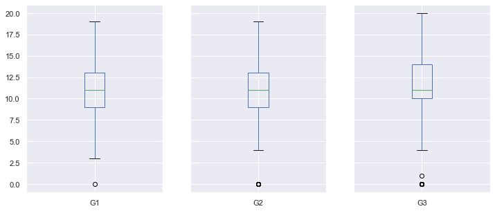

```python
data[['G1', 'G2', 'G3']].plot.box(subplots=True, layout=(1, 3), figsize=(12, 5), sharey=True)
```

```
array([[<AxesSubplot:ylabel='Frequency'>,
        <AxesSubplot:ylabel='Frequency'>,
        <AxesSubplot:ylabel='Frequency'>]], dtype=object)
```

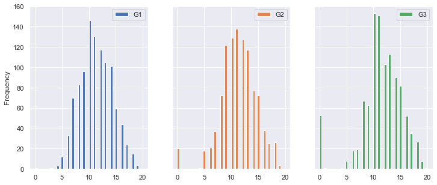

```python
data[['G1', 'G2', 'G3']].plot.hist(subplots=True, layout=(1, 3), figsize=(12, 5), sharey=True, bins=50)
```

```
array([[<AxesSubplot:ylabel='Density'>, <AxesSubplot:ylabel='Density'>,
        <AxesSubplot:ylabel='Density'>]], dtype=object)
```

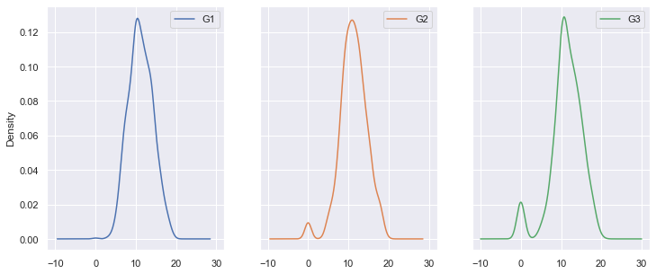

```python
data[['G1', 'G2', 'G3']].plot.density(subplots=True, layout=(1, 3), figsize=(12, 5), sharey=True)
```

В дальнейшем распределения будут показаны с использованием boxplot'ов (и violinplot'ов), т.к. они более кратки и репрезентативны

### Задание 6

Оцените попарные зависимости числовых признаков.  
Рассчитайте и провизуализируйте матрицу корреляций. Дайте содержательный комментарий.

[output not shown]

[output cut: 234 more lines]

[output not shown]

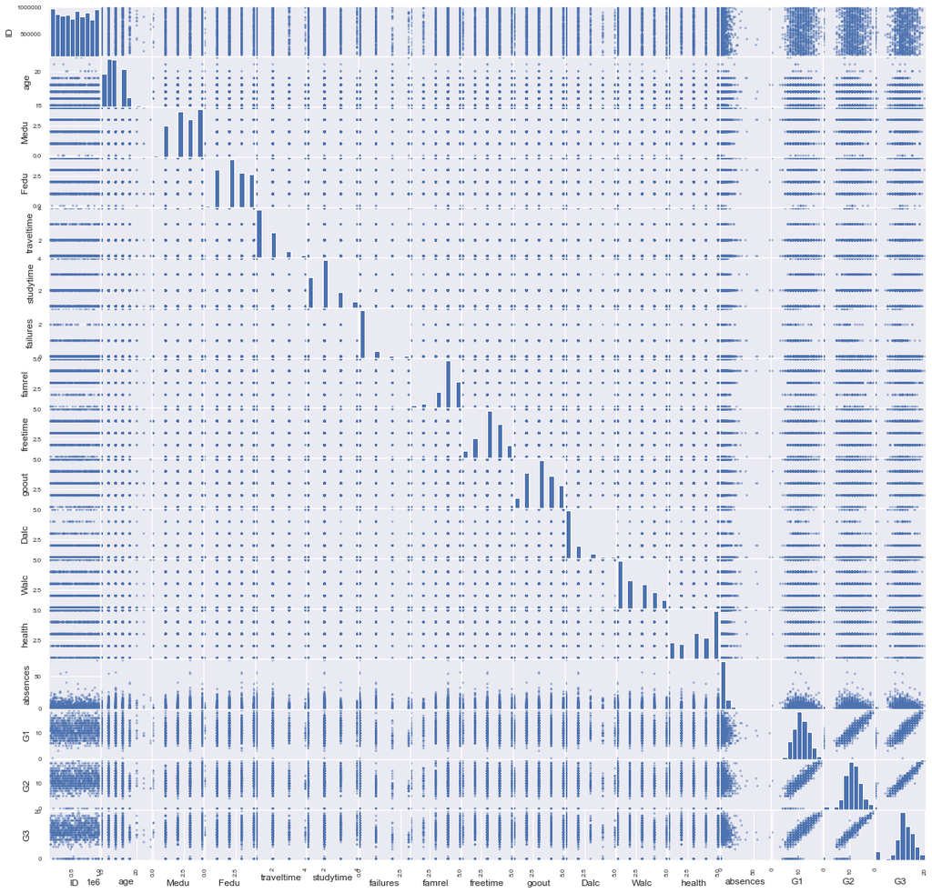

```python
pd.plotting.scatter_matrix(data[numeric_data], figsize=(20, 20))
```

Для большей наглядности лучше открывать изображение в новой вкладке

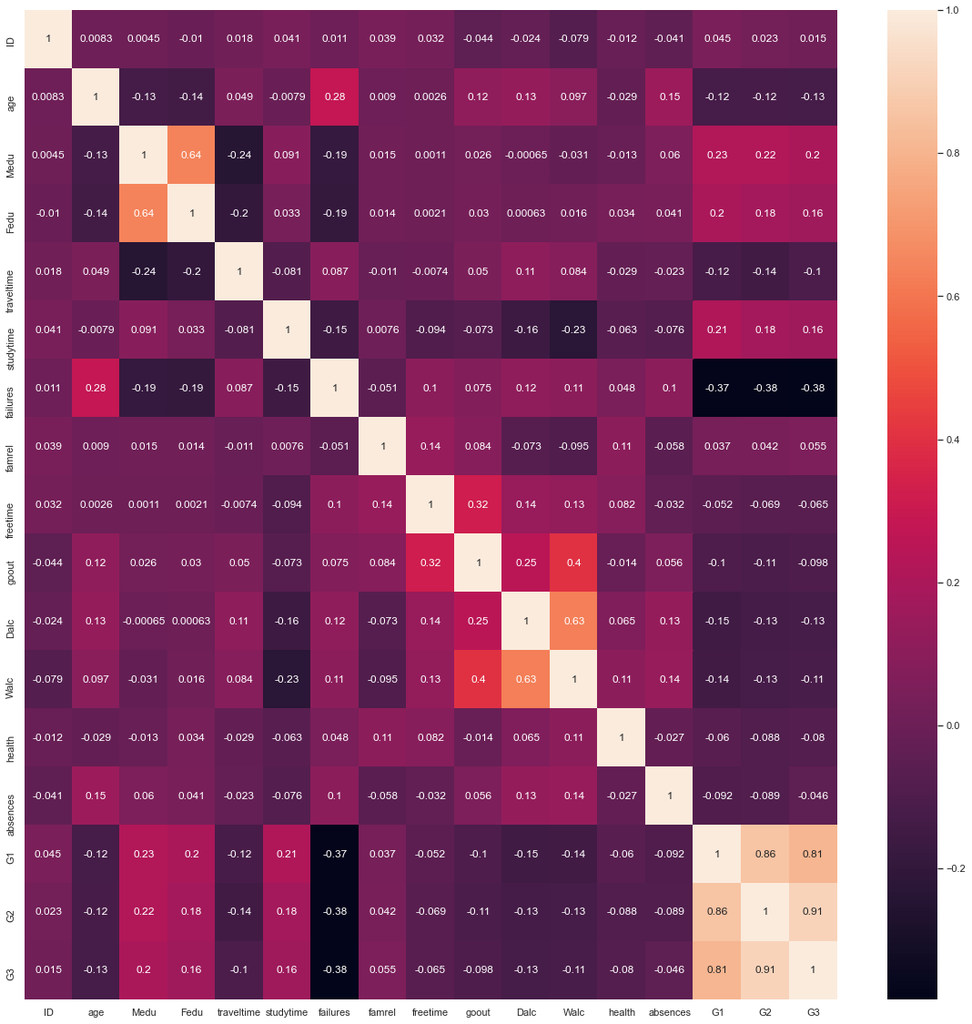

```python
fig, ax = plt.subplots(figsize=(20,20))

corr = data[numeric_data].corr()
sns.heatmap(corr, xticklabels=corr.columns, yticklabels=corr.columns, annot=True, ax=ax)
```

Как можно видеть, существует довольно большая корреляция между образованием родителей (скорее всего, родители знакомятся в одном учреждении и имеют схожее образование). Продолжая разговор об образовании родителей, можно заметить, что образование матери больше влияет на итоговые оценки, чем образование отца.

Также можно видеть, что существует зависимость между возрастом и числом заваленных экзаменов и между завалами и итоговыми оценками (чем меньше завалов, тем выше оценки, логично).

Влияние алкоголя (в любые дни) на время обучения влияет негативно, однако положительно на время до школы и на число заваленных экзаменов.Также есть сильная зависимость между распитием алкоголя в будни и в выходные.

Проведённое время с друзьями влияет на свободное время и распитие алкоголя.

Самя сильная зависимость между итоговыми оценками. Оценки будут высокими в семестре, если они были высокими в предыдущих периодах. Можно сказать, что те, кто учится хорошо, продолжат в том же темпе.

Интересно сильное влияние времени обучения на оценки - больше всего влияния оказывается на первое полугодие

### Задание 7

Оцените попарные зависимости нечисловых (категориальных) признаков, дайте содержательный комментарий.

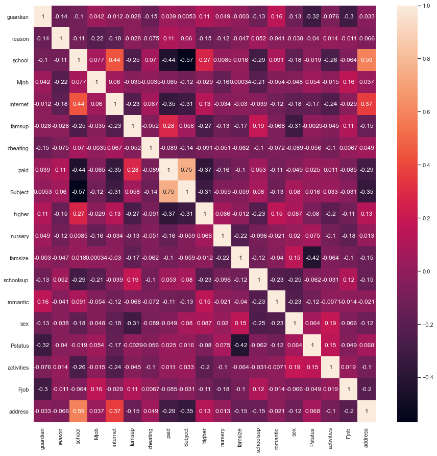

```python
fig, ax = plt.subplots(figsize=(15, 15))

categorical_data = list(set(data.columns) - set(numeric_data))

corr = data[categorical_data].apply(lambda x : pd.factorize(x)[0]).corr(method='pearson', min_periods=1).corr()
sns.heatmap(corr, xticklabels=corr.columns, yticklabels=corr.columns, annot=True, ax=ax)
```

Можно заметить, что на выбор предмета влияет платные занятия, адрес школы, интернет (видимо, число туториалов или отзывов) и школа. Также есть зависимость между наличием платных занятий и семейной поддержкой (нанятие репетиторов и можно считать поддержкой). Платные занятия влияют и на желание получить высшее образование.

На выбор школы наиболее сильно влияют адрес школы (скорее всего, чем ближе, тем лучше) и наличие интернета (возможно, доступ к отзывам или выпускникам).

Также можно заметить зависимость между интернетом и адресом (в загородных местах его, скорее всего, нет) и между статусом родителей и размером семьи (логично, если один из супругов ушёл, то размер семьи уменьшается). Статус родителей также влияет на опекуна.

### Задание 8

- Оцените, есть ли разница в употреблении алкоголя между парнями и девушками. Кто пьет больше?
- Оцените связь употребления алкоголя с признаками: address, Pstatus, higher, romantic, freetime.
- Оцените связь употребления алкоголя с уровнем образования опекуна (для случаев, где это известно).
- Сравните употребление алкоголя для 50 лучших учеников и 50 худших (по `G3`). Выполните сравнение отдельно для каждого предмета (`Math` и `Por`). Дайте содержательный комментарий.

**Tip:** для выполнения задания пригодятся боксплоты и гистограммы.

```python
data['Alc'] = [x + y for x, y in zip(data.Dalc, data.Walc)]
```

Очистим data от дупликатов, сохранив оригинал

```python
old_data = data.copy()
data = delete_dupl(data)
```

```
        Alc
sex
F    1779.0
M    1954.0
```

```
F         AxesSubplot(0.1,0.15;0.363636x0.75)
M    AxesSubplot(0.536364,0.15;0.363636x0.75)
dtype: object
```

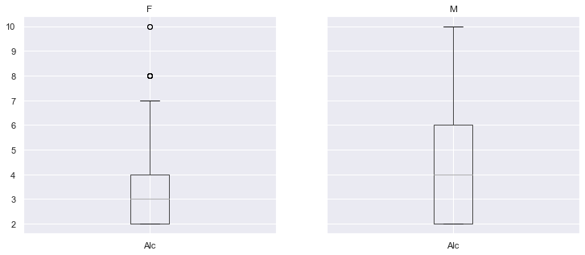

```python
print(data[['sex', 'Alc']].groupby('sex').sum())
data[['sex', 'Alc']].groupby('sex').boxplot(subplots=True, layout=(1, 2), figsize=(12, 5), sharey=True)
```

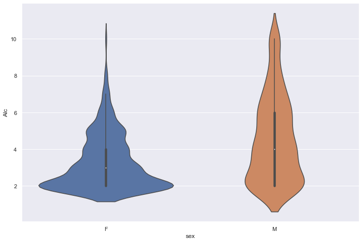

```python
sns.violinplot(x='sex', y='Alc', data=data)
```

**Парни пьют больше (и в среднем, и вообще)**

```
            Alc
address
R        1080.0
U        2653.0
```

```
R         AxesSubplot(0.1,0.15;0.363636x0.75)
U    AxesSubplot(0.536364,0.15;0.363636x0.75)
dtype: object
```

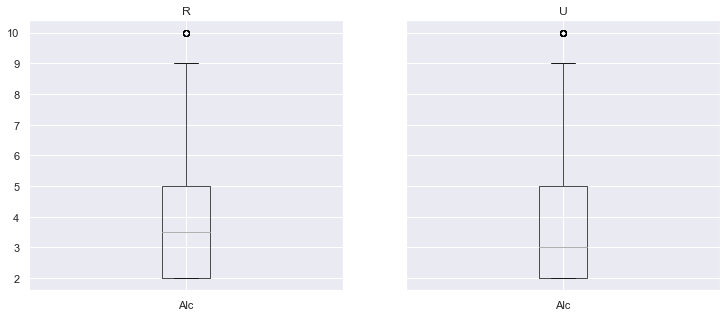

```python
print(data[['address', 'Alc']].groupby('address').sum())
data[['address', 'Alc']].groupby('address').boxplot(subplots=True, layout=(1, 2), figsize=(12, 5), sharey=True)
```

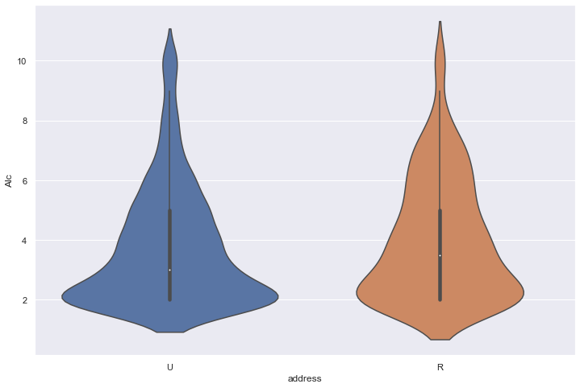

```python
sns.violinplot(x='address', y='Alc', data=data)
```

**Те, кто живут в городе выпили в целом больше, однако загородные в среднем пьют больше**

```
            Alc
Pstatus
A         421.0
T        3312.0
```

```
A         AxesSubplot(0.1,0.15;0.363636x0.75)
T    AxesSubplot(0.536364,0.15;0.363636x0.75)
dtype: object
```

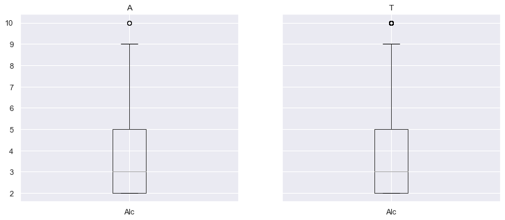

```python
print(data[['Pstatus', 'Alc']].groupby('Pstatus').sum())
data[['Pstatus', 'Alc']].groupby('Pstatus').boxplot(subplots=True, layout=(1, 2), figsize=(12, 5), sharey=True)
```

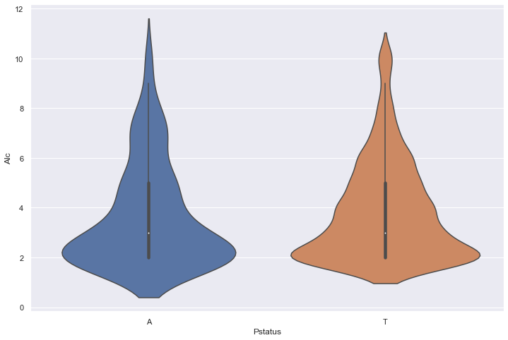

```python
sns.violinplot(x='Pstatus', y='Alc', data=data)
```

**Те, у кого родители вместе, выпили в общем значительно больше, но распределение одинаково**

```
           Alc
higher
no       385.0
yes     3348.0
```

```
no          AxesSubplot(0.1,0.15;0.363636x0.75)
yes    AxesSubplot(0.536364,0.15;0.363636x0.75)
dtype: object
```

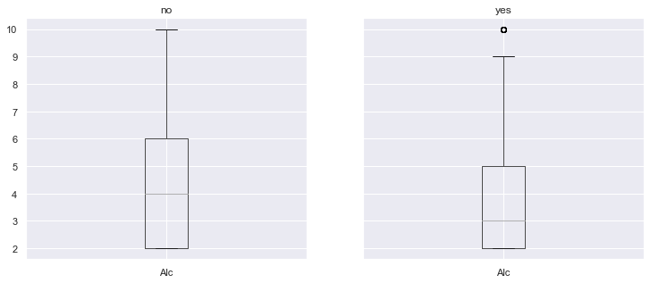

```python
print(data[['higher', 'Alc']].groupby('higher').sum())
data[['higher', 'Alc']].groupby('higher').boxplot(subplots=True, layout=(1, 2), figsize=(12, 5), sharey=True)
```

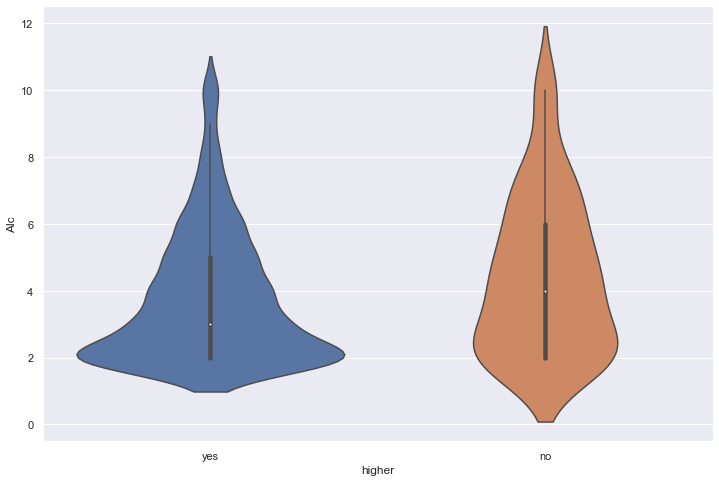

```python
sns.violinplot(x='higher', y='Alc', data=data)
```

**Те, кто собираются получать высшее, выпили в целом больше, но в среднем пьют меньше**

```
             Alc
romantic
no        2343.0
yes       1345.0
```

```
no          AxesSubplot(0.1,0.15;0.363636x0.75)
yes    AxesSubplot(0.536364,0.15;0.363636x0.75)
dtype: object
```

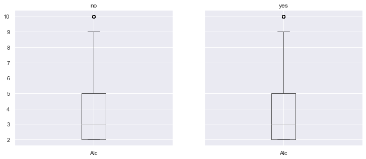

```python
print(data[['romantic', 'Alc']].groupby('romantic').sum())
data[['romantic', 'Alc']].groupby('romantic').boxplot(subplots=True, layout=(1, 2), figsize=(12, 5), sharey=True)
```

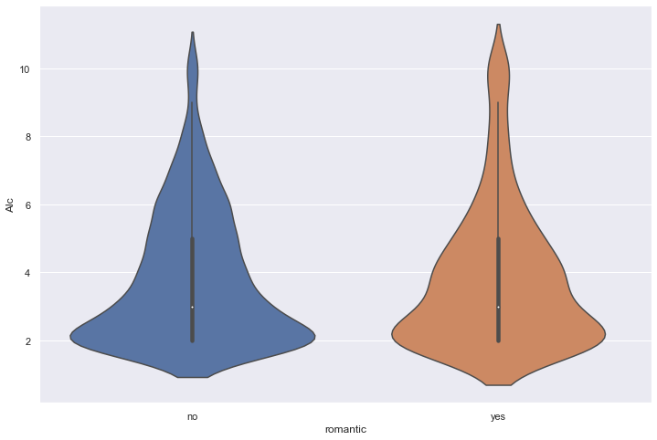

```python
sns.violinplot(x='romantic', y='Alc', data=data)
```

**Одинокие выпили больше, но распределения одинаковы**

```
             Alc
freetime
1          210.0
2          545.0
3         1362.0
4         1145.0
5          471.0
```

```
1         AxesSubplot(0.1,0.15;0.137931x0.75)
2    AxesSubplot(0.265517,0.15;0.137931x0.75)
3    AxesSubplot(0.431034,0.15;0.137931x0.75)
4    AxesSubplot(0.596552,0.15;0.137931x0.75)
5    AxesSubplot(0.762069,0.15;0.137931x0.75)
dtype: object
```

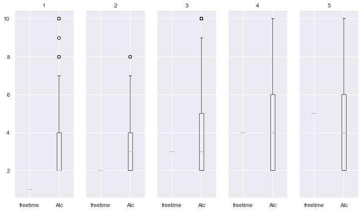

```python
print(data[['freetime', 'Alc']].groupby('freetime').sum())
data[['freetime', 'Alc']].groupby('freetime').boxplot(subplots=True, layout=(1, 5), figsize=(12, 7), sharey=True)
```

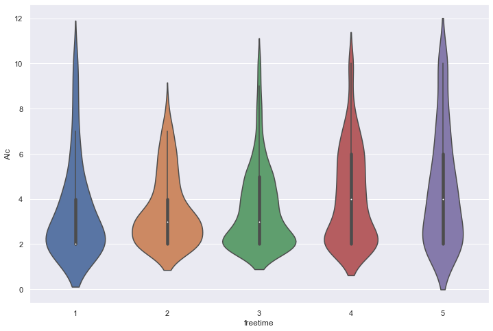

```python
sns.violinplot(x='freetime', y='Alc', data=data)
```

**Больше всего выпили те, у кого свободного времени много, но не очень много, а в среднем - чем больше свободного времени, тем больше пьют**

```
         Alc
Medu
0       32.0
1      770.0
2      952.0
3      920.0
4     1059.0
```

```
0         AxesSubplot(0.1,0.15;0.137931x0.75)
1    AxesSubplot(0.265517,0.15;0.137931x0.75)
2    AxesSubplot(0.431034,0.15;0.137931x0.75)
3    AxesSubplot(0.596552,0.15;0.137931x0.75)
4    AxesSubplot(0.762069,0.15;0.137931x0.75)
dtype: object
```

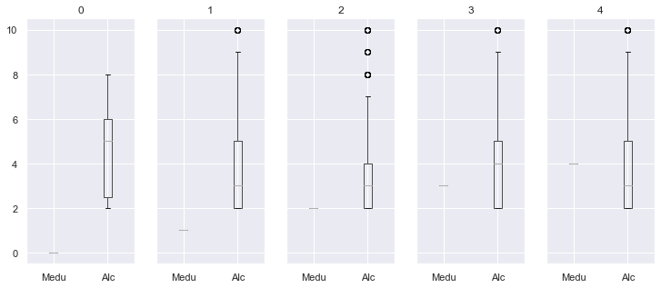

```python
print(data[['Medu', 'Alc']].groupby('Medu').sum())
data[['Medu', 'Alc']].groupby('Medu').boxplot(subplots=True, layout=(1, 5), figsize=(12, 5), sharey=True)
```

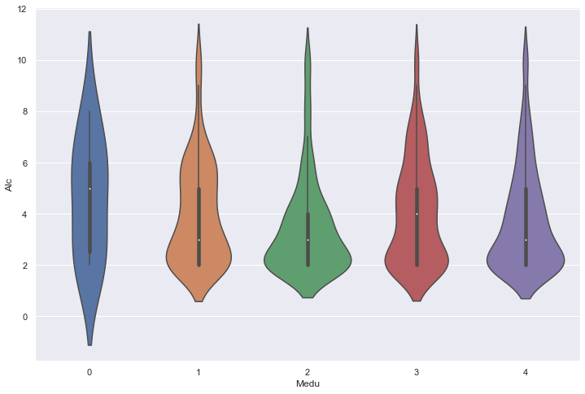

```python
sns.violinplot(x='Medu', y='Alc', data=data)
```

```
         Alc
Fedu
0       16.0
1      950.0
2     1156.0
3      803.0
4      808.0
```

```
0         AxesSubplot(0.1,0.15;0.137931x0.75)
1    AxesSubplot(0.265517,0.15;0.137931x0.75)
2    AxesSubplot(0.431034,0.15;0.137931x0.75)
3    AxesSubplot(0.596552,0.15;0.137931x0.75)
4    AxesSubplot(0.762069,0.15;0.137931x0.75)
dtype: object
```

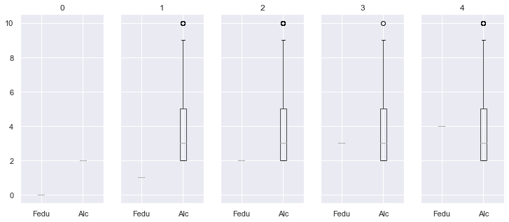

```python
print(data[['Fedu', 'Alc']].groupby('Fedu').sum())
data[['Fedu', 'Alc']].groupby('Fedu').boxplot(subplots=True, layout=(1, 5), figsize=(12, 5), sharey=True)
```

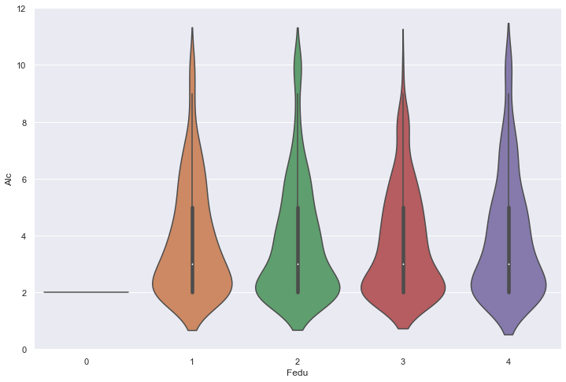

```python
sns.violinplot(x='Fedu', y='Alc', data=data)
```

**Больше всего выпили те, у кого отец закончил 5-9 классов, но распределения похожи**

```python
# 50 лучших и 50 худших
data = old_data.copy()  # вернём оригинальные данные
worst_50 = data.sort_values(by='G3').head(50)
best_50 = data.sort_values(by='G3').tail(50)
```

```python
print(worst_50[['G3', 'Alc']].groupby('G3').sum())
print(best_50[['G3', 'Alc']].groupby('G3').sum())
```

```
      Alc
G3
0   182.0
     Alc
G3
17  42.0
18  78.0
19  16.0
20   2.0
```

```python
pd.crosstab(index=worst_50.G3, columns=worst_50.Subject, values=worst_50.Alc, aggfunc='sum')
```

| Subject G3 | Math | Por |
| --- | --- | --- |
| 0 | 119.0 | 63.0 |

```python
pd.crosstab(index=best_50.G3, columns=best_50.Subject, values=best_50.Alc, aggfunc='sum')
```

| Subject G3 | Math | Por |
| --- | --- | --- |
| 17 | 4.0 | 38.0 |
| 18 | 37.0 | 41.0 |
| 19 | 9.0 | 7.0 |
| 20 | 2.0 | NaN |

**Для всех:**

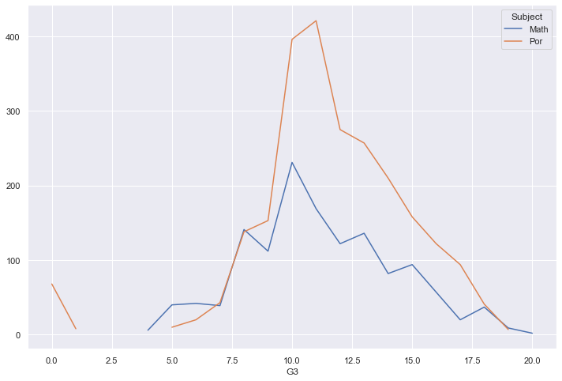

```python
pd.crosstab(index=data.G3, columns=data.Subject, values=data.Alc, aggfunc='sum').plot()
```